# HR Predictive Analytics Project – Monitoring Turnover Risk

Kevin Allen Cauley

May 02, 2025

## 1 Predictive Modeling on Monitoring Turnover Risk

The goal of this modeling section is to predict **Monitoring Turnover Risk** using a set of behavioral, demographic, and engagement-related predictors.

We will evaluate a range of classification models using multiple **resampling strategies** (No Sampling, Up-Sampling, Down-Sampling, and SMOTE). Models will be evaluated using six classification metrics:

- Accuracy
- Precision
- Recall
- F1 Score
- Specificity
- ROC AUC

This approach ensures fairness, robustness, and clarity in identifying the most effective model and configuration.

### 1.1 Shared Model Setup - Monitoring Turnover Risk

```r
# Ensure Monitoring Turnover Risk is a Factor
hr_df <- hr_df %>%
  mutate(Monitoring_Turnover_Risk = as.factor(Monitoring_Turnover_Risk))

# Set Seed
set.seed(42)

# 80/20 train/test split with stratification
mtr_split <- initial_split(hr_df, prop = 0.8, strata = Monitoring_Turnover_Risk)
mtr_train_data <- training(mtr_split)
mtr_test_data  <- testing(mtr_split)

# 10-Fold Cross Validation
mtr_folds <- vfold_cv(mtr_train_data, v = 10, strata = Monitoring_Turnover_Risk)

# Shared Pre-processing (no resampling)
base_recipe <- recipe(Monitoring_Turnover_Risk ~ ., data = mtr_train_data) %>%
  step_dummy(all_nominal_predictors()) %>%
  step_zv(all_predictors()) %>%
  step_normalize(all_numeric_predictors())

# Basic Logistic Model
logit_model <- logistic_reg() %>%
  set_engine("glm") %>%
  set_mode("classification")
```

```r
# Shared metric set for all models
all_metrics <- metric_set(accuracy, precision, recall, f_meas, yardstick::spec, roc_auc)
```

## 2 Monitoring Turnover Risk with Logistic Regression

### 2.1 Logistic Regression - No Resampling

```r
# Workflow with Base Recipe
workflow_logit_none <- workflow() %>%
  add_model(logit_model) %>%
  add_recipe(base_recipe)

# Fit to training data
fit_logit_none <- fit(workflow_logit_none, data = mtr_train_data)

# Predict on test data
logit_preds_none <- predict(fit_logit_none, new_data = mtr_test_data, type = "prob") %>%
  bind_cols(predict(fit_logit_none, new_data = mtr_test_data)) %>%
  bind_cols(mtr_test_data %>% select(Monitoring_Turnover_Risk))
```

### 2.2 Logistic Regression - No Resampling - Performance Metrics

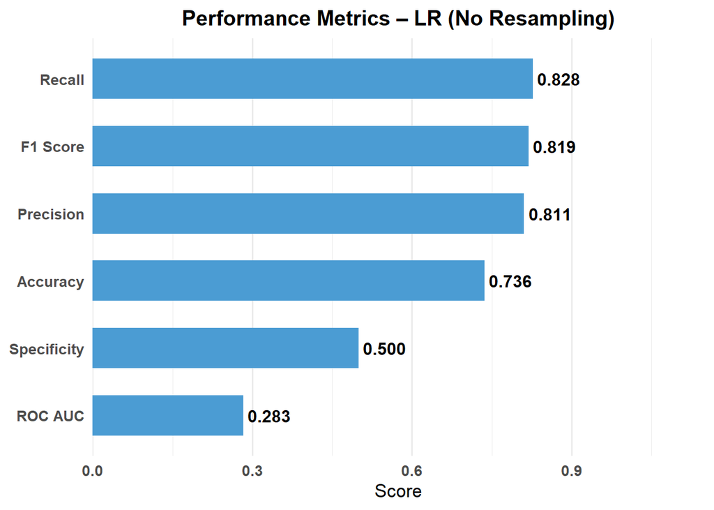

```r
# Metrics
logit_none_metrics <- all_metrics(logit_preds_none, truth = Monitoring_Turnover_Risk, estimate = .pred_class, .pred_Yes)

# Plot
logit_none_metrics %>%
  filter(.metric %in% c("accuracy", "precision", "recall", "f_meas", "spec", "roc_auc")) %>%
  mutate(.metric = factor(.metric,
                          levels = c("accuracy", "precision", "recall", "f_meas", "spec", "roc_auc"),
                          labels = c("Accuracy", "Precision", "Recall", "F1 Score", "Specificity", "ROC AUC"))) %>%
  ggplot(aes(x = .estimate, y = fct_reorder(.metric, .estimate))) +
  geom_col(fill = "#4B9CD3", width = 0.6) +
  geom_text(aes(label = sprintf("%.3f", .estimate)),
            hjust = -0.1, color = "black", size = 4.2, fontface = "bold") +
  scale_x_continuous(limits = c(0, 1), expand = expansion(mult = c(0, 0.15))) +
  labs(
    title = "Performance Metrics – LR (No Resampling)",
    x = "Score", y = NULL
  ) +
  theme_minimal(base_size = 13) +
  theme(
    plot.title = element_text(face = "bold", size = 15, hjust = 0.5),
    axis.text = element_text(face = "bold"),
    panel.grid.major.y = element_blank()
  )
```

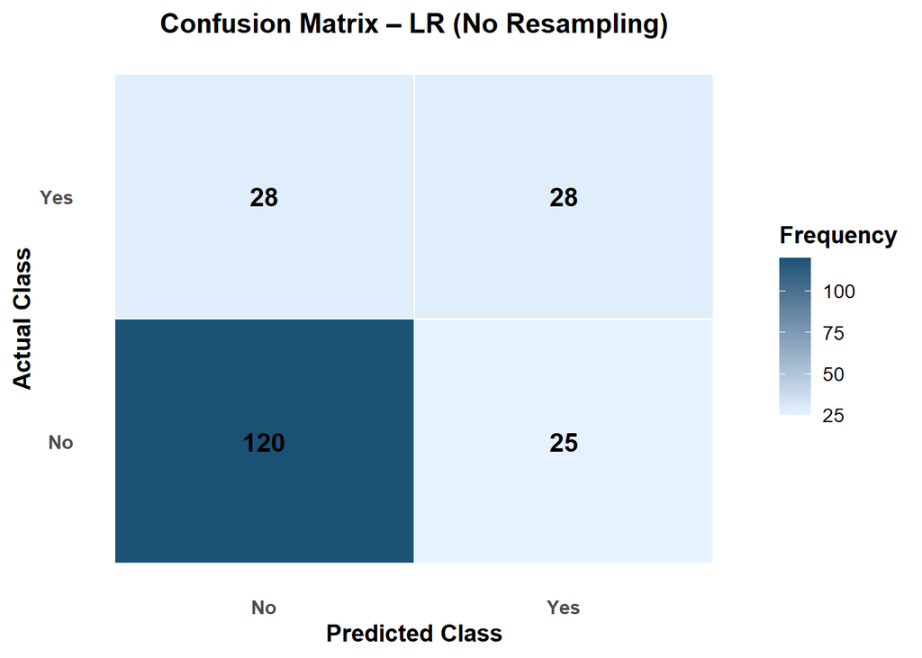

```r
library(ggplot2)
library(yardstick)
library(forcats)

# Confusion matrix to dataframe
cm_logit_none <- conf_mat(logit_preds_none, truth = Monitoring_Turnover_Risk, estimate = .pred_class)
cm_df <- as.data.frame(cm_logit_none$table)

# Ensure proper order for plotting
cm_df$Truth <- factor(cm_df$Truth, levels = c("Yes", "No"))
cm_df$Prediction <- factor(cm_df$Prediction, levels = c("No", "Yes"))

# Plot
ggplot(cm_df, aes(x = Prediction, y = Truth, fill = Freq)) +
  geom_tile(color = "white", linewidth = 0.5) +
  geom_text(aes(label = Freq), color = "black", size = 5, fontface = "bold") +
  scale_fill_gradient(low = "#e6f2ff", high = "#1A5276", name = "Frequency") +
  scale_y_discrete(limits = rev) +
  labs(
    title = "Confusion Matrix – LR (No Resampling)",
    x = "Predicted Class",
    y = "Actual Class"
  ) +
  theme_minimal(base_size = 13) +
  theme(
    plot.title = element_text(face = "bold", hjust = 0.5, size = 15),
    axis.title = element_text(face = "bold"),
    axis.text = element_text(face = "bold"),
    legend.title = element_text(face = "bold"),
    panel.grid = element_blank()
  )
```

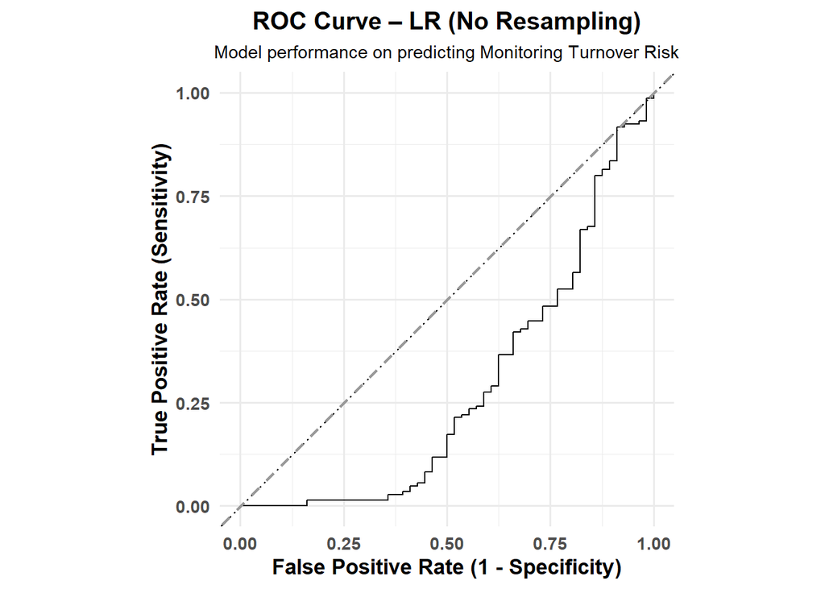

```r
# Generate ROC curve
roc_curve(logit_preds_none, truth = Monitoring_Turnover_Risk, .pred_Yes) %>%
  autoplot() +
  geom_abline(linetype = "dashed", color = "gray60", size = 0.8) +
  labs(
    title = "ROC Curve – LR (No Resampling)",
    subtitle = "Model performance on predicting Monitoring Turnover Risk",
    x = "False Positive Rate (1 - Specificity)",
    y = "True Positive Rate (Sensitivity)"
  ) +
  theme_minimal(base_size = 13) +
  theme(
    plot.title = element_text(face = "bold", size = 15, hjust = 0.5),
    plot.subtitle = element_text(hjust = 0.5, size = 11),
    axis.title = element_text(face = "bold"),
    axis.text = element_text(face = "bold")
  )
```

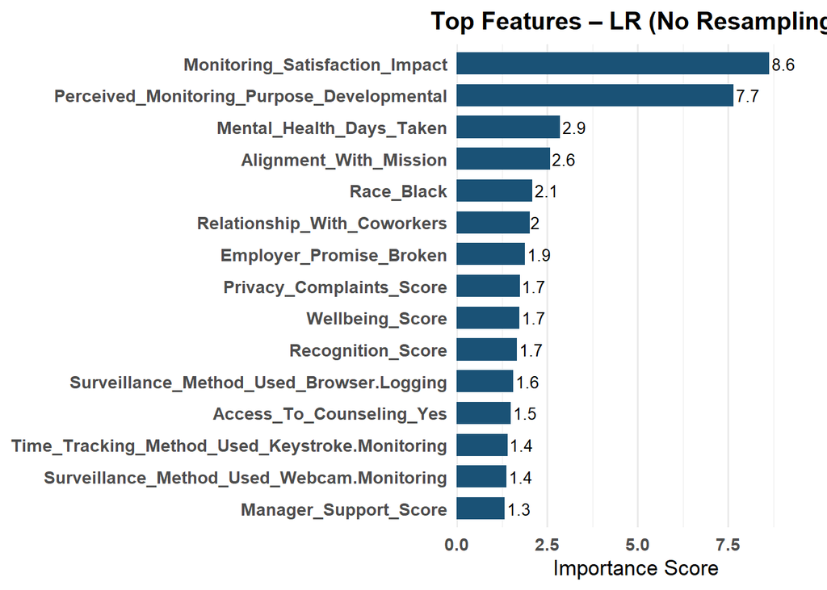

```r
# Extract full importance and then limit to top 15
vip_logit_none <- fit_logit_none %>%
  extract_fit_parsnip() %>%
  vi() %>%
  arrange(desc(Importance)) %>%
  slice_head(n = 15) %>%
  mutate(Variable = fct_reorder(Variable, Importance))

# Plot
ggplot(vip_logit_none, aes(x = Importance, y = Variable)) +
  geom_col(fill = "#1A5276", width = 0.7) +
  geom_text(aes(label = round(Importance, 1)), hjust = -0.1, color = "black", size = 3.5) +
  scale_x_continuous(expand = expansion(mult = c(0, 0.15))) +
  labs(
    title = "Top Features – LR (No Resampling)",
    x = "Importance Score", y = NULL
  ) +
  theme_minimal(base_size = 13) +
  theme(
    plot.title = element_text(face = "bold", hjust = 0.5, size = 15),
    axis.text = element_text(face = "bold"),
    panel.grid.major.y = element_blank()
  )
```

### 2.3 Logistic Regression – SMOTE

```r
# SMOTE recipe
recipe_logit_smote <- base_recipe %>%
  step_smote(Monitoring_Turnover_Risk)

workflow_logit_smote <- workflow() %>%
  add_model(logit_model) %>%
  add_recipe(recipe_logit_smote)

# 10-Fold CV
set.seed(42)
logit_cv_smote <- fit_resamples(
  workflow_logit_smote,
  resamples = mtr_folds,
  metrics = metric_set(accuracy, precision, recall, f_meas, yardstick::spec, roc_auc)
)

# Final model fit and prediction on test data for SMOTE
fit_logit_smote <- fit(workflow_logit_smote, data = mtr_train_data)

logit_preds_smote <- predict(fit_logit_smote, new_data = mtr_test_data, type = "prob") %>%
  bind_cols(predict(fit_logit_smote, new_data = mtr_test_data)) %>%
  bind_cols(mtr_test_data %>% select(Monitoring_Turnover_Risk))
```

### 2.4 Logistic Regression – SMOTE - Performance Metrics

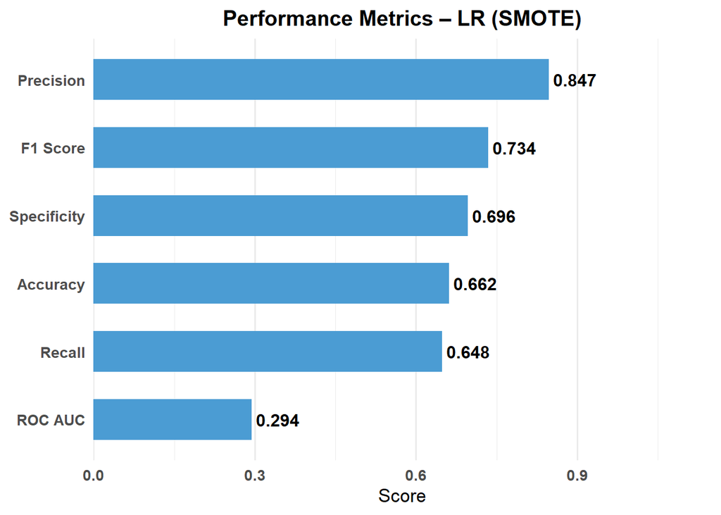

```r
# Metrics
logit_smote_metrics <- all_metrics(logit_preds_smote, truth = Monitoring_Turnover_Risk, estimate = .pred_class, .pred_Yes)

# Plot
logit_smote_metrics %>%
  filter(.metric %in% c("accuracy", "precision", "recall", "f_meas", "spec", "roc_auc")) %>%
  mutate(.metric = factor(.metric,
                          levels = c("accuracy", "precision", "recall", "f_meas", "spec", "roc_auc"),
                          labels = c("Accuracy", "Precision", "Recall", "F1 Score", "Specificity", "ROC AUC"))) %>%
  ggplot(aes(x = .estimate, y = fct_reorder(.metric, .estimate))) +
  geom_col(fill = "#4B9CD3", width = 0.6) +
  geom_text(aes(label = sprintf("%.3f", .estimate)),
            hjust = -0.1, color = "black", size = 4.2, fontface = "bold") +
  scale_x_continuous(limits = c(0, 1), expand = expansion(mult = c(0, 0.15))) +
  labs(
    title = "Performance Metrics – LR (SMOTE)",
    x = "Score", y = NULL
  ) +
  theme_minimal(base_size = 13) +
  theme(
    plot.title = element_text(face = "bold", size = 15, hjust = 0.5),
    axis.text = element_text(face = "bold"),
    panel.grid.major.y = element_blank()
  )
```

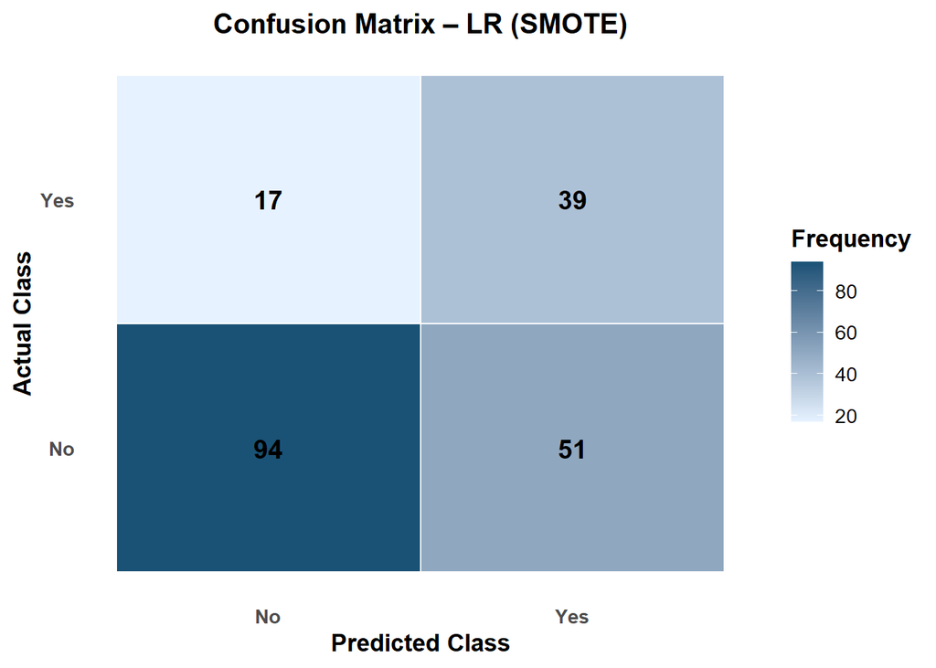

```r
# Create confusion matrix
cm_logit_smote <- conf_mat(logit_preds_smote, truth = Monitoring_Turnover_Risk, estimate = .pred_class)
cm_df_smote <- as.data.frame(cm_logit_smote$table)

# Order axes
cm_df_smote$Truth <- factor(cm_df_smote$Truth, levels = c("Yes", "No"))
cm_df_smote$Prediction <- factor(cm_df_smote$Prediction, levels = c("No", "Yes"))

# Plot heatmap
ggplot(cm_df_smote, aes(x = Prediction, y = Truth, fill = Freq)) +
  geom_tile(color = "white", linewidth = 0.5) +
  geom_text(aes(label = Freq), color = "black", size = 5, fontface = "bold") +
  scale_fill_gradient(low = "#e6f2ff", high = "#1A5276", name = "Frequency") +
  scale_y_discrete(limits = rev) +  # YES on top
  labs(
    title = "Confusion Matrix – LR (SMOTE)",
    x = "Predicted Class",
    y = "Actual Class"
  ) +
  theme_minimal(base_size = 13) +
  theme(
    plot.title = element_text(face = "bold", hjust = 0.5, size = 15),
    axis.title = element_text(face = "bold"),
    axis.text = element_text(face = "bold"),
    legend.title = element_text(face = "bold"),
    panel.grid = element_blank()
  )
```

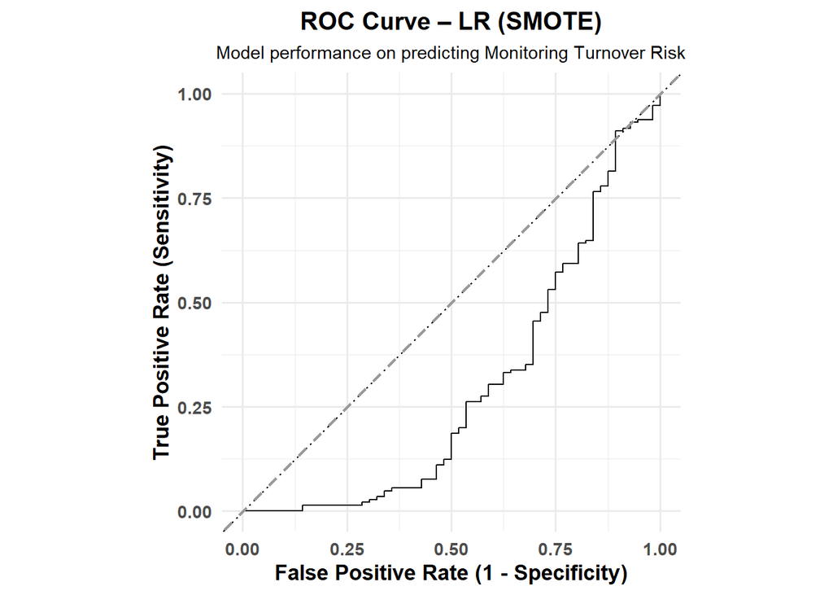

```r
# ROC Curve
roc_curve(logit_preds_smote, truth = Monitoring_Turnover_Risk, .pred_Yes) %>%
  autoplot() +
  geom_abline(linetype = "dashed", color = "gray60", size = 0.8) +
  labs(
    title = "ROC Curve – LR (SMOTE)",
    subtitle = "Model performance on predicting Monitoring Turnover Risk",
    x = "False Positive Rate (1 - Specificity)",
    y = "True Positive Rate (Sensitivity)"
  ) +
  theme_minimal(base_size = 13) +
  theme(
    plot.title = element_text(face = "bold", size = 15, hjust = 0.5),
    plot.subtitle = element_text(hjust = 0.5, size = 11),
    axis.title = element_text(face = "bold"),
    axis.text = element_text(face = "bold")
  )
```

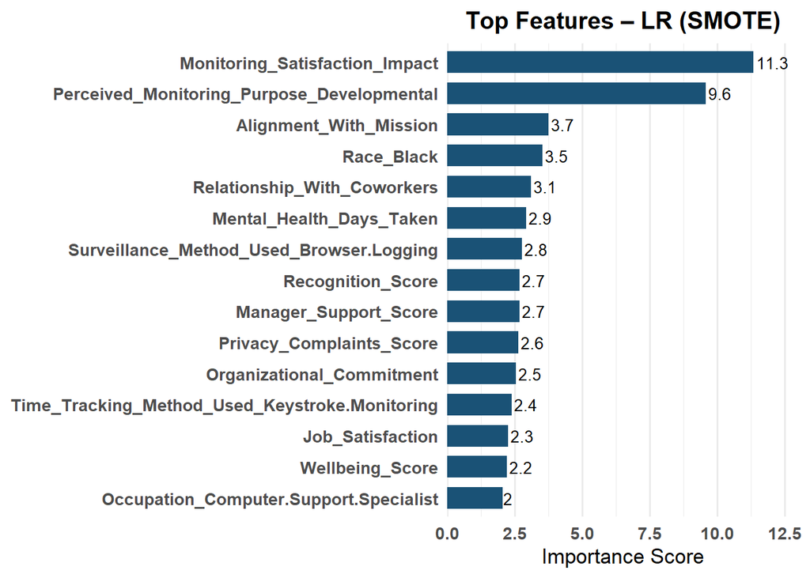

```r
# Top 15 features only
fit_logit_smote %>%
  extract_fit_parsnip() %>%
  vi() %>%
  arrange(desc(Importance)) %>%
  slice_head(n = 15) %>%
  mutate(Variable = fct_reorder(Variable, Importance)) %>%
  ggplot(aes(x = Importance, y = Variable)) +
  geom_col(fill = "#1A5276", width = 0.7) +
  geom_text(aes(label = round(Importance, 1)), hjust = -0.1, color = "black", size = 3.5) +
  scale_x_continuous(expand = expansion(mult = c(0, 0.15))) +
  labs(
    title = "Top Features – LR (SMOTE)",
    x = "Importance Score", y = NULL
  ) +
  theme_minimal(base_size = 13) +
  theme(
    plot.title = element_text(face = "bold", hjust = 0.5, size = 15),
    axis.text = element_text(face = "bold"),
    panel.grid.major.y = element_blank()
  )
```

### 2.5 Logistic Regression - Upsampling

```r
# Upsampling Recipe
recipe_logit_upsample <- base_recipe %>%
  step_upsample(Monitoring_Turnover_Risk)

# Workflow
workflow_logit_upsample <- workflow() %>%
  add_model(logit_model) %>%
  add_recipe(recipe_logit_upsample)

# Fit
fit_logit_upsample <- fit(workflow_logit_upsample, data = mtr_train_data)

# Predict
logit_preds_upsample <- predict(fit_logit_upsample, new_data = mtr_test_data, type = "prob") %>%
  bind_cols(predict(fit_logit_upsample, new_data = mtr_test_data)) %>%
  bind_cols(mtr_test_data %>% select(Monitoring_Turnover_Risk))
```

### 2.6 Logistic Regression - Upsampling - Performance Metrics

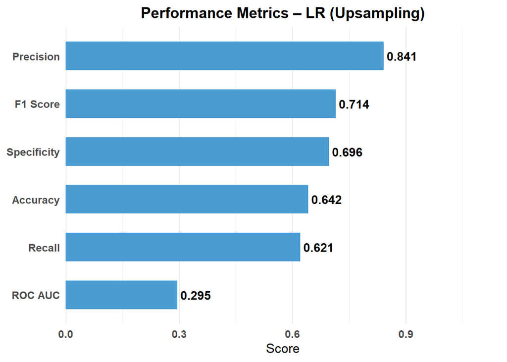

```r
# Metrics
logit_upsample_metrics <- all_metrics(logit_preds_upsample, truth = Monitoring_Turnover_Risk, estimate = .pred_class, .pred_Yes)

# Plot
logit_upsample_metrics %>%
  filter(.metric %in% c("accuracy", "precision", "recall", "f_meas", "spec", "roc_auc")) %>%
  mutate(.metric = factor(.metric,
                          levels = c("accuracy", "precision", "recall", "f_meas", "spec", "roc_auc"),
                          labels = c("Accuracy", "Precision", "Recall", "F1 Score", "Specificity", "ROC AUC"))) %>%
  ggplot(aes(x = .estimate, y = fct_reorder(.metric, .estimate))) +
  geom_col(fill = "#4B9CD3", width = 0.6) +
  geom_text(aes(label = sprintf("%.3f", .estimate)),
            hjust = -0.1, color = "black", size = 4.2, fontface = "bold") +
  scale_x_continuous(limits = c(0, 1), expand = expansion(mult = c(0, 0.15))) +
  labs(
    title = "Performance Metrics – LR (Upsampling)",
    x = "Score", y = NULL
  ) +
  theme_minimal(base_size = 13) +
  theme(
    plot.title = element_text(face = "bold", size = 15, hjust = 0.5),
    axis.text = element_text(face = "bold"),
    panel.grid.major.y = element_blank()
  )
```

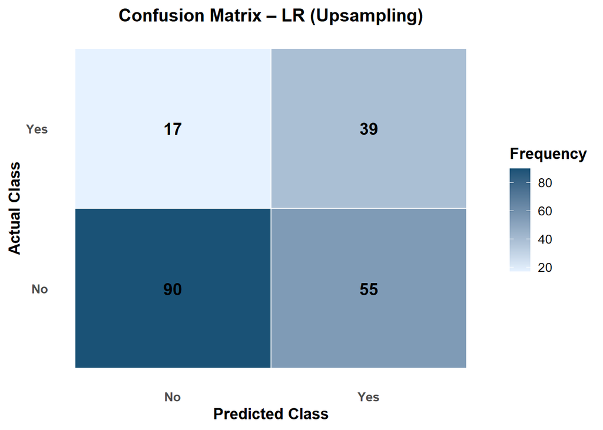

```r
# Confusion matrix data prep
cm_logit_upsample <- conf_mat(logit_preds_upsample, truth = Monitoring_Turnover_Risk, estimate = .pred_class)
cm_df_upsample <- as.data.frame(cm_logit_upsample$table)

# Set factor levels to match layout: Yes on top, No bottom; No left, Yes right
cm_df_upsample$Truth <- factor(cm_df_upsample$Truth, levels = c("Yes", "No"))
cm_df_upsample$Prediction <- factor(cm_df_upsample$Prediction, levels = c("No", "Yes"))

# Plot
ggplot(cm_df_upsample, aes(x = Prediction, y = Truth, fill = Freq)) +
  geom_tile(color = "white", linewidth = 0.5) +
  geom_text(aes(label = Freq), color = "black", size = 5, fontface = "bold") +
  scale_fill_gradient(low = "#e6f2ff", high = "#1A5276", name = "Frequency") +
  scale_y_discrete(limits = rev) +
  labs(
    title = "Confusion Matrix – LR (Upsampling)",
    x = "Predicted Class",
    y = "Actual Class"
  ) +
  theme_minimal(base_size = 13) +
  theme(
    plot.title = element_text(face = "bold", hjust = 0.5, size = 15),
    axis.title = element_text(face = "bold"),
    axis.text = element_text(face = "bold"),
    legend.title = element_text(face = "bold"),
    panel.grid = element_blank()
  )
```

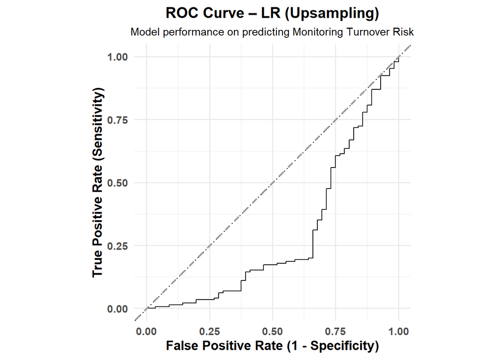

```r
# Roc
roc_curve(logit_preds_upsample, truth = Monitoring_Turnover_Risk, .pred_Yes) %>%
  autoplot() +
  geom_abline(linetype = "dashed", color = "gray60", size = 0.8) +
  labs(
    title = "ROC Curve – LR (Upsampling)",
    subtitle = "Model performance on predicting Monitoring Turnover Risk",
    x = "False Positive Rate (1 - Specificity)",
    y = "True Positive Rate (Sensitivity)"
  ) +
  theme_minimal(base_size = 13) +
  theme(
    plot.title = element_text(face = "bold", hjust = 0.5, size = 15),
    plot.subtitle = element_text(hjust = 0.5, size = 11),
    axis.title = element_text(face = "bold"),
    axis.text = element_text(face = "bold")
  )
```

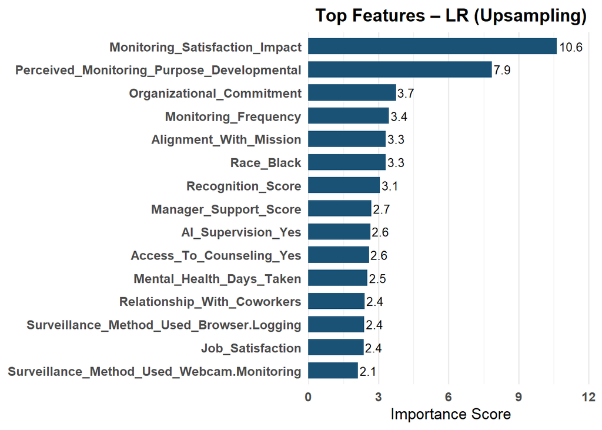

```r
# Styled VIP for top 15 features
fit_logit_upsample %>%
  extract_fit_parsnip() %>%
  vi() %>%
  arrange(desc(Importance)) %>%
  slice_head(n = 15) %>%
  mutate(Variable = fct_reorder(Variable, Importance)) %>%
  ggplot(aes(x = Importance, y = Variable)) +
  geom_col(fill = "#1A5276", width = 0.7) +
  geom_text(aes(label = round(Importance, 1)), hjust = -0.1, color = "black", size = 3.5) +
  scale_x_continuous(expand = expansion(mult = c(0, 0.15))) +
  labs(
    title = "Top Features – LR (Upsampling)",
    x = "Importance Score", y = NULL
  ) +
  theme_minimal(base_size = 13) +
  theme(
    plot.title = element_text(face = "bold", hjust = 0.5, size = 15),
    axis.text = element_text(face = "bold"),
    panel.grid.major.y = element_blank()
  )
```

### 2.7 Logistic Regression - Downsampling

```r
# Downsampling Recipe
recipe_logit_downsample <- base_recipe %>%
  step_downsample(Monitoring_Turnover_Risk)

# Workflow
workflow_logit_downsample <- workflow() %>%
  add_model(logit_model) %>%
  add_recipe(recipe_logit_downsample)

# Fit on training data
fit_logit_downsample <- fit(workflow_logit_downsample, data = mtr_train_data)

# Predict on test data
logit_preds_downsample <- predict(fit_logit_downsample, new_data = mtr_test_data, type = "prob") %>%
  bind_cols(predict(fit_logit_downsample, new_data = mtr_test_data)) %>%
  bind_cols(mtr_test_data %>% select(Monitoring_Turnover_Risk))
```

### 2.8 Logistic Regression - Downsampling - Performance Metrics

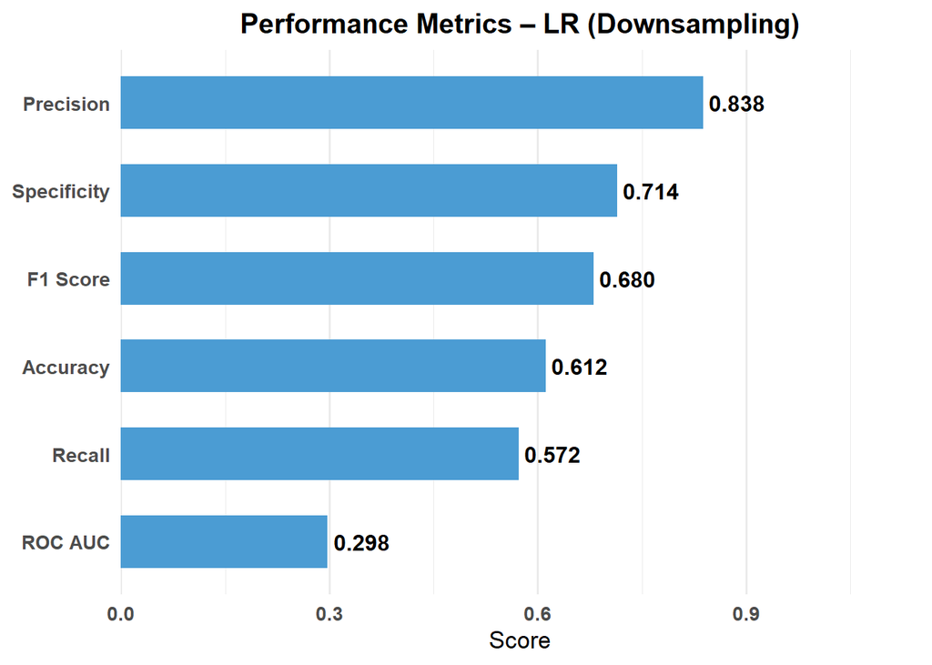

```r
# Metrics
logit_downsample_metrics <- all_metrics(logit_preds_downsample, truth = Monitoring_Turnover_Risk, estimate = .pred_class, .pred_Yes)

# Plot
logit_downsample_metrics %>%
  filter(.metric %in% c("accuracy", "precision", "recall", "f_meas", "spec", "roc_auc")) %>%
  mutate(.metric = factor(.metric,
                          levels = c("accuracy", "precision", "recall", "f_meas", "spec", "roc_auc"),
                          labels = c("Accuracy", "Precision", "Recall", "F1 Score", "Specificity", "ROC AUC"))) %>%
  ggplot(aes(x = .estimate, y = fct_reorder(.metric, .estimate))) +
  geom_col(fill = "#4B9CD3", width = 0.6) +
  geom_text(aes(label = sprintf("%.3f", .estimate)),
            hjust = -0.1, color = "black", size = 4.2, fontface = "bold") +
  scale_x_continuous(limits = c(0, 1), expand = expansion(mult = c(0, 0.15))) +
  labs(
    title = "Performance Metrics – LR (Downsampling)",
    x = "Score", y = NULL
  ) +
  theme_minimal(base_size = 13) +
  theme(
    plot.title = element_text(face = "bold", size = 15, hjust = 0.5),
    axis.text = element_text(face = "bold"),
    panel.grid.major.y = element_blank()
  )
```

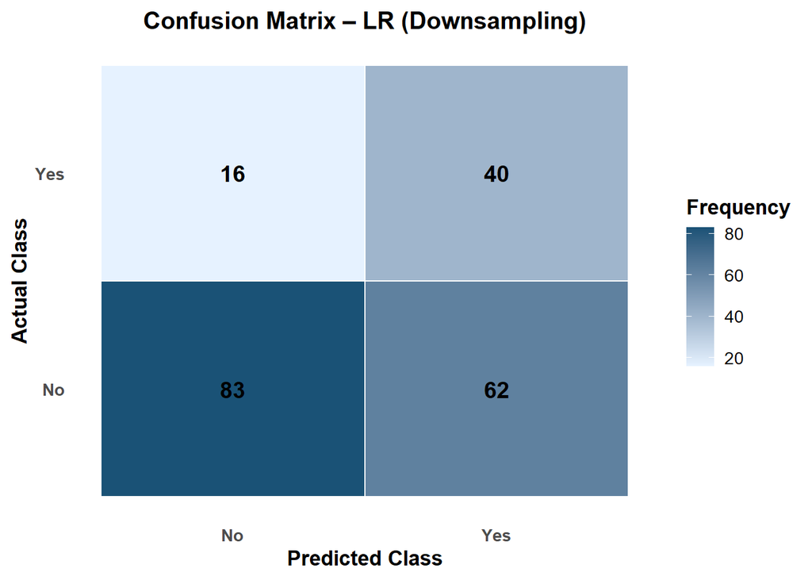

```r
cm_logit_down <- conf_mat(logit_preds_downsample, truth = Monitoring_Turnover_Risk, estimate = .pred_class)
cm_df_down <- as.data.frame(cm_logit_down$table)

cm_df_down$Truth <- factor(cm_df_down$Truth, levels = c("Yes", "No"))
cm_df_down$Prediction <- factor(cm_df_down$Prediction, levels = c("No", "Yes"))

ggplot(cm_df_down, aes(x = Prediction, y = Truth, fill = Freq)) +
  geom_tile(color = "white", linewidth = 0.5) +
  geom_text(aes(label = Freq), color = "black", size = 5, fontface = "bold") +
  scale_fill_gradient(low = "#e6f2ff", high = "#1A5276", name = "Frequency") +
  scale_y_discrete(limits = rev) +
  labs(
    title = "Confusion Matrix – LR (Downsampling)",
    x = "Predicted Class",
    y = "Actual Class"
  ) +
  theme_minimal(base_size = 13) +
  theme(
    plot.title = element_text(face = "bold", hjust = 0.5, size = 15),
    axis.title = element_text(face = "bold"),
    axis.text = element_text(face = "bold"),
    legend.title = element_text(face = "bold"),
    panel.grid = element_blank()
  )
```

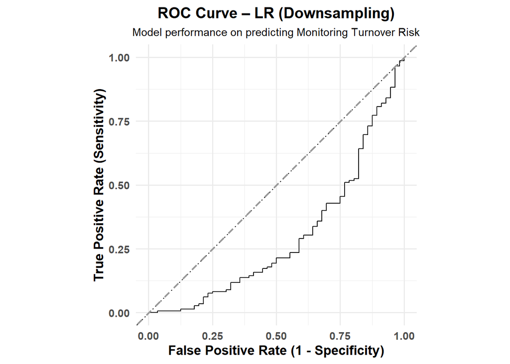

```r
roc_curve(logit_preds_downsample, truth = Monitoring_Turnover_Risk, .pred_Yes) %>%
  autoplot() +
  geom_abline(linetype = "dashed", color = "gray60", size = 0.8) +
  labs(
    title = "ROC Curve – LR (Downsampling)",
    subtitle = "Model performance on predicting Monitoring Turnover Risk",
    x = "False Positive Rate (1 - Specificity)",
    y = "True Positive Rate (Sensitivity)"
  ) +
  theme_minimal(base_size = 13) +
  theme(
    plot.title = element_text(face = "bold", size = 15, hjust = 0.5),
    plot.subtitle = element_text(hjust = 0.5, size = 11),
    axis.title = element_text(face = "bold"),
    axis.text = element_text(face = "bold")
  )
```

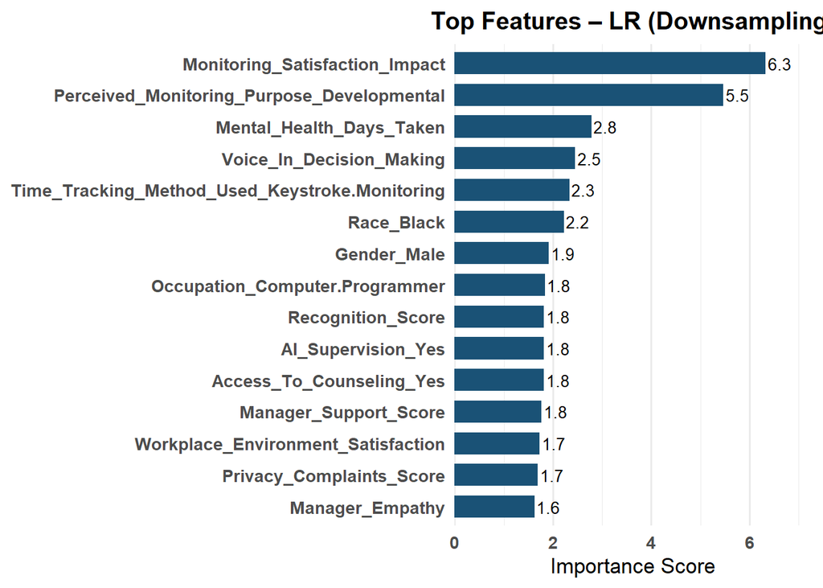

```r
fit_logit_downsample %>%
  extract_fit_parsnip() %>%
  vi() %>%
  arrange(desc(Importance)) %>%
  slice_head(n = 15) %>%
  mutate(Variable = fct_reorder(Variable, Importance)) %>%
  ggplot(aes(x = Importance, y = Variable)) +
  geom_col(fill = "#1A5276", width = 0.7) +
  geom_text(aes(label = round(Importance, 1)), hjust = -0.1, color = "black", size = 3.5) +
  scale_x_continuous(expand = expansion(mult = c(0, 0.15))) +
  labs(
    title = "Top Features – LR (Downsampling)",
    x = "Importance Score", y = NULL
  ) +
  theme_minimal(base_size = 13) +
  theme(
    plot.title = element_text(face = "bold", hjust = 0.5, size = 15),
    axis.text = element_text(face = "bold"),
    panel.grid.major.y = element_blank()
  )
```